# DD7ans

## Deep Dive #7 - Matrix exponentials

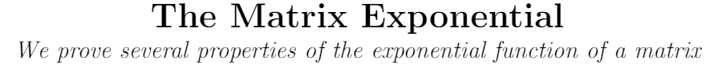

What's next, Matrix Taylor expansion? ...wait

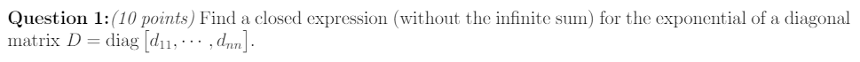

Find $e^D$ in terms of $D = \text{diag}[d_{11},\cdots,d_{nn}]=\text{diag}[\lambda_1,\cdots,\lambda_n]$

Well, we can use the infinite sum to find the closed expression.

$$ e^{A} = \sum_{n=0}^{\infty}\frac{A^n}{n!}=I + \frac{A}{1}+\frac{A^2}{2!}+\cdots+\frac{A^n}{n!} $$

We'll also use $$ D^n =\text{diag}[d_{11}^n,\cdots,d_{nn}^n] $$

$$ e^D=\sum_{k=0}^{\infty}\frac{D^k}{k!}=\sum_{k=0}^{\infty}\frac{1}{k!}\text{diag}[d_{11}^k,\cdots,d_{nn}^k]\\ =\text{diag}\left[\sum_{k=0}\frac{d_{11}^k}{k!},\cdots,\sum_{k=0}\frac{d_{nn}^k}{k!}\right]=\text{diag}\left[e^{d_{11}},\cdots,e^{d_{nn}} \right] $$

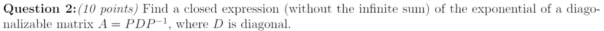

$$ e^A=e^{PDP^{-1}} =\sum_{k=0}^{\infty}\frac{(PDP^{-1})^k}{k!} $$ This yields a chain of $PDP^{-1}$ s which yields $$ (PDP^{-1})^k=PDP^{-1}PDP^{-1}PDP^{-1}\dots\\ =PDIDIDP^{-1}\dots =PD^kP^{-1} $$ Which gives us $$ \sum_{k=0}^{\infty}\frac{(PDP^{-1})^k}{k!} = \sum_{k=0}^{\infty}\frac{PD^kP^{-1}}{k!}=P\sum_{k=0}^{\infty}\frac{D^k}{k!}P^{-1}= Pe^DP^{-1} $$

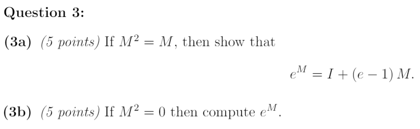

3a

Using the infinite sum $$ e^{M} =I + \frac{M}{1}+\frac{M^2}{2!}+\cdots+\frac{M^n}{n!} $$ but $M^2 = M$ and $M^3 = M^2 M = MM=M$ and $M^n=M$, giving us $$ e^M = I + \sum_{k=1}^{\infty} \frac{M}{k!} = I + \sum_{k=0}^{\infty} \frac{M}{k!} - M \\= I + \sum_{k=0}^{\infty} (\frac{1}{k!}-1)M\\ =I + (e-1)M $$

3b

$$ e^M = I + M + 0 + \frac{0*M}{3!} + ... + \frac{0*M^{n-2}}{n!} = I+M $$

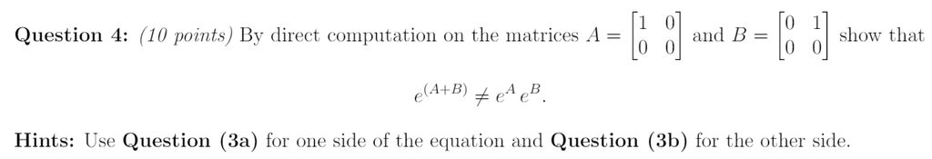

$$ (A+B)^2=(A+B)\\ A^2 =A\\ B^2=0\\ e^{(A+B)}=I+(e-1)(A+B) \\ e^Ae^B = (I+(e-1)A)(I+B) $$ I'll leave distribution as an exercise for the reader. These aren't equivalent

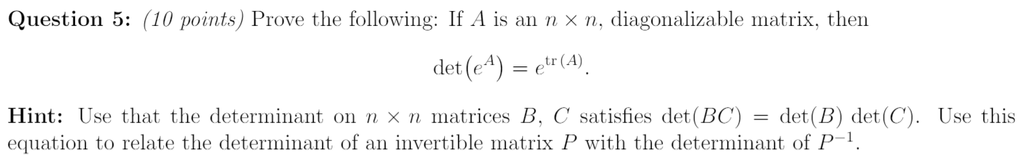

Pf. Show $\text{det}(e^A)=e^{\text{tr}(A)}$

$$ \text{det}\left(e^A\right)=\text{det}\left(Pe^DP^{-1}\right)=\text{det}(P)\text{det}(e^D)\text{det}(P^{-1})\\ =\text{det}(P)\text{det}(P^{-1})\text{det}(e^D)=\text{det}(PP^{-1})\text{det}(e^D) \\ =\text{det}(e^D)=\text{det}(\text{diag}\left[e^{d_{11}},\cdots,e^{d_{nn}} \right])=e^{d_{11}}e^{d_{22}}\cdots e^{d_{nn}}=e^{d_{11}+d_{22}+\cdots+d_{nn}} \\ =e^{\text{tr}D}=e^{\text{tr}A} $$ Since tr($A$) is equal to the sum of its eigenvalues, and the elements of $D$ are the eigenvalues of $A$

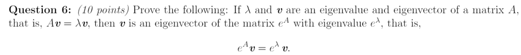

Note: for $Av=\lambda v,\ A^kv=\lambda^kv$. This comes from $A^2v=A(Av)=A(\lambda v)=\lambda Av = \lambda^2 v$. The full proof can be done via induction.

Pf. $$ e^A v = Iv + Av + \frac{A^2v}{2}+\dots+\frac{A^nv}{n!} \\ = Iv + \lambda v + \frac{\lambda^2v}{2}+\dots+\frac{\lambda^nv}{n!} = e^\lambda v $$

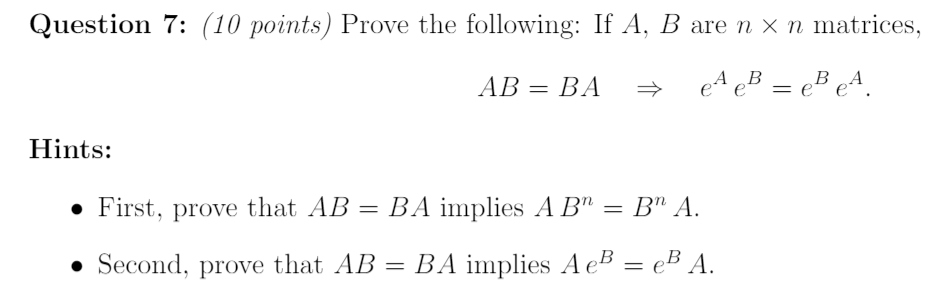

Part 1: $AB=BA \implies AB^n=B^nA$

$$BAB=B^2A \\ (BA)B = (AB)B \\ BAB = AB^2=B^2A$$ Using this process gives us $$ B^{k-1}AB^1 = B^k A \\ B^{k-2}AB^2 = B^k A \\ B^{k-3}AB^3 = B^k A \\ \vdots\\ B^{k-k}AB^k = IAB^k = AB^k = B^kA $$

Part 2: $AB=BA \implies Ae^B = e^B A$

$$ Ae^B = A\left(I+\frac{B}{1}+\frac{B^2}{2!}+\cdots+\frac{B^n}{n!}\right) \\ =AI+\frac{AB}{1}+\frac{AB^2}{2!}+\cdots+\frac{AB^n}{n!} \\ =IA+\frac{BA}{1}+\frac{B^2A}{2!}+\cdots+\frac{B^nA}{n!} = \left(I+\frac{B}{1}+\frac{B^2}{2!}+\cdots+\frac{B^n}{n!}\right)A \\ = e^B A $$

Pf. Show $AB=BA \implies e^Ae^B=e^Be^A$

$$ e^Ae^B = e^A\left(I+\frac{B}{1}+\frac{B^2}{2!}+\cdots+\frac{B^n}{n!}\right) \\ =e^AI+\frac{e^AB}{1}+\frac{e^AB^2}{2!}+\cdots+\frac{e^AB^n}{n!} $$ Since $e^AB=Be^A$ we have $e^AB^k=B^ke^A$ $$ =Ie^A+\frac{Be^A}{1}+\frac{B^2e^A}{2!}+\cdots+\frac{B^ne^A}{n!} = \left(I+\frac{B}{1}+\frac{B^2}{2!}+\cdots+\frac{B^n}{n!}\right) e^A\\ = e^B e^A $$